# HE plot MMRA Examples

Michael Friendly

2026-10-04

Vignette built using `heplots`, version 1.8.6 and `candisc`, version 1.1.1.

# Multivariate Multiple Regression Designs

The ideas behind HE plots extend naturally to multivariate multiple regression (MMRA) and multivariate analysis of covariance (MANCOVA). In MMRA designs, the $\mathbf{X}$ matrix contains only quantitative predictors, while in MANCOVA designs, it contains a mixture of factors and quantitative predictors (covariates), but typically there is just one “group” factor.

In the MANCOVA case, there is often a subtle difference in emphasis: true MANCOVA analyses focus on the differences among groups defined by the factors, **adjusting for** (or controlling for) the quantitative covariates. Analyses concerned with **homogeneity of regression** focus on quantitative predictors and attempt to test whether the regression relations are the same for all groups defined by the factors.

# 1 Rohwer data: Aptitude and achievement

To illustrate the homogeneity of regression flavor, we use data from a study by Rohwer (given in Timm (1975), Ex. 4.3, 4.7, and 4.23) on kindergarten children, designed to determine how well a set of paired-associate (PA) tasks predicted performance on measures of achievement:

- the Peabody Picture Vocabulary test (`PPVT`),
- a student achievement test (`SAT`), and
- the Raven Progressive matrices test (`Raven`).

The PA tasks were considered measures of learning aptitude and varied in how the stimuli were presented, and are called *named* (`n`), *still* (`s`), *named still* (`ns`), *named action* (`na`), and *sentence still* (`ss`).

Two groups were tested: a group of $n=37$ children from a low socioeconomic status (SES) school, and a group of $n=32$ high SES children from an upper-class, white residential school. The data are in the data frame `Rohwer` in the `heplots` package:

```r
data(Rohwer)
Rohwer |> dplyr::sample_n(6)
```

```
#>    group SES SAT PPVT Raven n  s ns na ss
#> 31     1  Lo   9   63    11 2 12  5 25 14
#> 7      1  Lo   6   71    21 0  1 20 23 18
#> 18     1  Lo  45   54    10 0  6  6 14 16
#> 17     1  Lo  19   66    13 7 12 21 35 27
#> 50     2  Hi   4   87    14 1  4 14 25 19
#> 59     2  Hi  36   89    15 1  6 15 23 28
```

## 1.1 Preliminary plots

Before fitting models, it is usually useful to do some data exploration and graphing. With multivariate multiple regression data, among the most helpful plots are scatterplots of each response variable, Y, against each predictor, X, and we can get a better sense of the relationships by adding linear regression lines, loess smooths or other enhancements.

This turned out to be not as easy as it might seem, because none of the `pairs()` methods allow for this possibility. The trick is to reshape the data from wide to long format and use facets in `ggplot2` to compose the pairwise scatterplots into the desired rectangular matrix format.

```r
library(tidyr)
library(dplyr)
library(ggplot2)

yvars <- c("SAT", "PPVT", "Raven" )      # outcome variables
xvars <- c("n", "s", "ns", "na", "ss")   # predictors
xvars <- c("n", "s", "ns")               # make a smaller example

Rohwer_long <- Rohwer %>%
  dplyr::select(-group, -na, -ss) |>
  tidyr::pivot_longer(cols = all_of(xvars),
                      names_to = "xvar", values_to = "x") |>
  tidyr::pivot_longer(cols = all_of(yvars),
                      names_to = "yvar", values_to = "y") |>
  dplyr::mutate(xvar = factor(xvar, levels = xvars),
                yvar = factor(yvar, levels = yvars))
Rohwer_long
```

```
#> # A tibble: 621 × 5
#>    SES   xvar      x yvar      y
#>    <fct> <fct> <int> <fct> <int>
#>  1 Lo    n         1 SAT      49
#>  2 Lo    n         1 PPVT     48
#>  3 Lo    n         1 Raven     8
#>  4 Lo    s         2 SAT      49
#>  5 Lo    s         2 PPVT     48
#>  6 Lo    s         2 Raven     8
#>  7 Lo    ns        6 SAT      49
#>  8 Lo    ns        6 PPVT     48
#>  9 Lo    ns        6 Raven     8
#> 10 Lo    n         5 SAT      47
#> # ℹ 611 more rows
```

Then, we can use `ggplot2` to make produce the pairwise plots for each combination of `x` and `y` variables. Using `color=SES` in the aesthetic results in a separate regression line for the two SES groups produced by `geom_smooth()`.

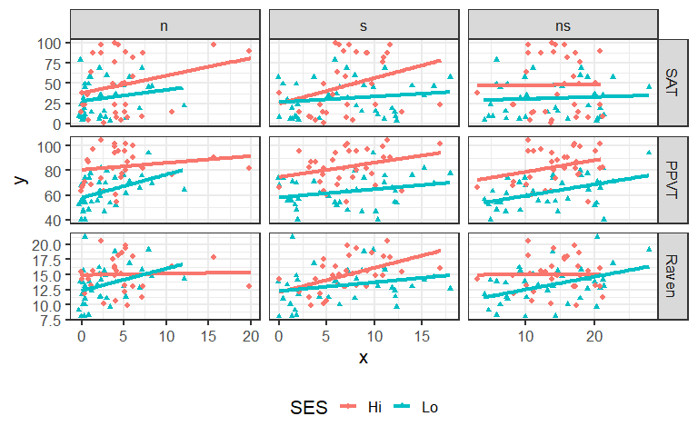

Figure 1.1: Plot matrix of the response variables (`SAT`, `PPVT` and `Raven`) against each of three predictors (`n`, `s`, `ns`). The lines show separate linear regressions for each SES group.

```r
ggplot(Rohwer_long, aes(x, y, color = SES, shape = SES)) +
  geom_jitter(size=1.5) +
  geom_smooth(method = "lm",
              se = FALSE,
              formula = y ~ x,
              size=1.5) +
  facet_grid(yvar ~ xvar,            # plot matrix of Y by X
             scales = "free") +
  theme_bw(base_size = 16) +
  theme(legend.position = "bottom")
```

Such plots form a framework for understanding model fits and statistical tests we turn to now.

## 1.2 Separate models

As one approach, we might be tempted to fit separate regression models for each of the High and Low SES groups. This approach is *not* generally recommended because it lacks power (smaller sample sizes in each group than a combined analysis) and does not allow hypotheses about equality of slopes and intercepts to be tested directly.

```r
rohwer.ses1 <- lm(cbind(SAT, PPVT, Raven) ~ n + s + ns + na + ss, data=Rohwer,
                  subset=SES=="Hi")
Anova(rohwer.ses1)
```

```
#>
#> Type II MANOVA Tests: Pillai test statistic
#>    Df test stat approx F num Df den Df Pr(>F)
#> n   1     0.202     2.02      3     24 0.1376
#> s   1     0.310     3.59      3     24 0.0284 *
#> ns  1     0.358     4.46      3     24 0.0126 *
#> na  1     0.465     6.96      3     24 0.0016 **
#> ss  1     0.089     0.78      3     24 0.5173
#> ---
#> Signif. codes:  0 '***' 0.001 '**' 0.01 '*' 0.05 '.' 0.1 ' ' 1
```

```r
rohwer.ses2 <- lm(cbind(SAT, PPVT, Raven) ~ n + s + ns + na + ss, data=Rohwer,
                  subset=SES=="Lo")
Anova(rohwer.ses2)
```

```
#>
#> Type II MANOVA Tests: Pillai test statistic
#>    Df test stat approx F num Df den Df Pr(>F)
#> n   1    0.0384     0.39      3     29  0.764
#> s   1    0.1118     1.22      3     29  0.321
#> ns  1    0.2252     2.81      3     29  0.057 .
#> na  1    0.2675     3.53      3     29  0.027 *
#> ss  1    0.1390     1.56      3     29  0.220
#> ---
#> Signif. codes:  0 '***' 0.001 '**' 0.01 '*' 0.05 '.' 0.1 ' ' 1
```

This fits separate slopes and intercepts for each of the two groups, but it is difficult to compare the coefficients numerically.

```r
coef(rohwer.ses1)
```

```
#>                  SAT     PPVT    Raven
#> (Intercept) -28.4675 39.69709 13.24384
#> n             3.2571  0.06728  0.05935
#> s             2.9966  0.36998  0.49244
#> ns           -5.8591 -0.37438 -0.16402
#> na            5.6662  1.52301  0.11898
#> ss           -0.6227  0.41016 -0.12116
```

```r
coef(rohwer.ses2)
```

```
#>                  SAT     PPVT    Raven
#> (Intercept)  4.15106 33.00577 11.17338
#> n           -0.60887 -0.08057  0.21100
#> s           -0.05016 -0.72105  0.06457
#> ns          -1.73240 -0.29830  0.21358
#> na           0.49456  1.47042 -0.03732
#> ss           2.24772  0.32396 -0.05214
```

The function `heplots::coefplot()` makes this a bit easier, by plotting bivariate confidence ellipses for the coefficients in a multivariate linear model. In this problem, with three response variables, the 95% confidence regions are 3D ellipsoids, but we only plot them in 2D. The 3D versions have the property that a given predictor is significant by a multivariate test if the ellipsoid excludes the point (0, 0, 0).

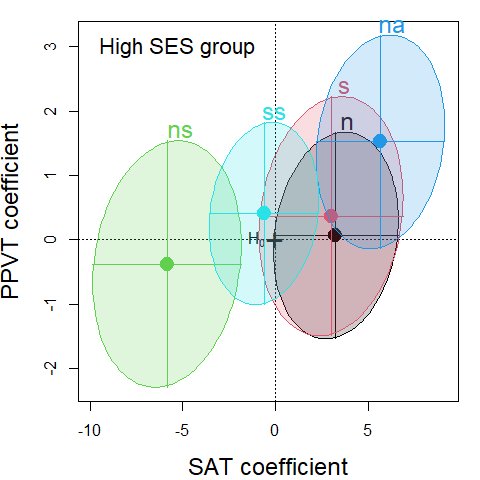

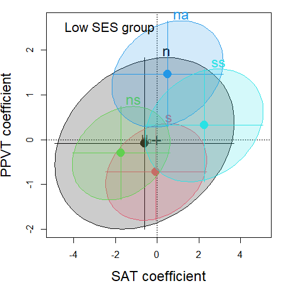

Figure 1.2: Coefficient plots for the separate models for the High and Low SES groups in the Rohwer data. The ellipses are 95% confidence regions for the pairs of regression coefficients of (SAT, PPVT) for each predictor in the model.

```r
coefplot(rohwer.ses1, fill=TRUE, cex.label=1.5, cex.lab=1.5)
text(-10, 3, "High SES group", pos=4, cex=1.4)

coefplot(rohwer.ses2, fill=TRUE, cex.label=1.5, cex.lab=1.5)
text(-4.7, 2.5, "Low SES group", pos=4, cex=1.4)
```

Alternatively, we can visualize the results of the multivariate tests for the predictors with HE plots. Here we make use of the fact that several HE plots can be overlaid using the option `add=TRUE` as shown in Figure 1.3.

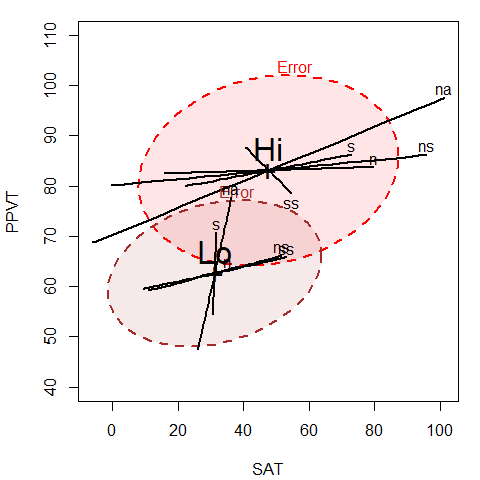

Figure 1.3: HE plot for `SAT` and `PPVT`, showing the effects for the PA predictors for the High and Low SES groups separately

```r
heplot(rohwer.ses1,
       ylim=c(40,110),                        # allow more room for 2nd plot
       col=c("red", "black"),
       fill = TRUE, fill.alpha = 0.1,
       lwd=2, cex=1.2)
heplot(rohwer.ses2,
       add=TRUE,
       col=c("brown", "black"),
       grand.mean=TRUE, error.ellipse=TRUE,   # not shown by default when add=TRUE
       fill = TRUE, fill.alpha = 0.1,
       lwd=2, cex=1.2)
# label the groups at their centroid
means <- aggregate(cbind(SAT,PPVT)~SES, data=Rohwer,  mean)
text(means[,2], means[,3], labels=means[,1], pos=3, cex=2, col="black")
```

We can readily see the difference in means for the two SES groups (`Hi` has greater scores on both variables) and it also appears that the slopes of the predictor ellipses are shallower for the High than the Low group, indicating greater relation with the `SAT` score.

## 1.3 MANCOVA model

Alternatively (and optimistically), we can fit a MANCOVA model that allows different means for the two SES groups on the responses, but constrains the slopes for the PA covariates to be equal.

```r
# MANCOVA, assuming equal slopes
Rohwer.mod <- lm(cbind(SAT, PPVT, Raven) ~ SES + n + s + ns + na + ss,
                 data=Rohwer)
Anova(Rohwer.mod)
```

```
#>
#> Type II MANOVA Tests: Pillai test statistic
#>     Df test stat approx F num Df den Df  Pr(>F)
#> SES  1     0.379    12.18      3     60 2.5e-06 ***
#> n    1     0.040     0.84      3     60  0.4773
#> s    1     0.093     2.04      3     60  0.1173
#> ns   1     0.193     4.78      3     60  0.0047 **
#> na   1     0.231     6.02      3     60  0.0012 **
#> ss   1     0.050     1.05      3     60  0.3770
#> ---
#> Signif. codes:  0 '***' 0.001 '**' 0.01 '*' 0.05 '.' 0.1 ' ' 1
```

Note that, although the multivariate tests for two of the covariates (`ns` and `na`) are highly significant, univariate multiple regression tests for the separate responses [from `summary(Rohwer.mod)`] are relatively weak.

We can also test the global 5 df hypothesis, $\mathbf{B}=\mathbf{0}$, that *all* covariates have null effects for all responses as a linear hypothesis. First, extract the names of the PA tests predictors from the model. `car::linearHypothesis()` takes a vector of the names coefficients to be tested simultaneously.

```r
covariates  <- c("n", "s", "ns", "na", "ss")
# or: covariates <- rownames(coef(Rohwer.mod))[-(1:2)]
```

```r
Regr <- linearHypothesis(Rohwer.mod, covariates)
print(Regr, digits=4, SSP=FALSE)
```

```
#>
#> Multivariate Tests:
#>                  Df test stat approx F num Df den Df   Pr(>F)
#> Pillai            5    0.6658    3.537     15    186 2.31e-05 ***
#> Wilks             5    0.4418    3.812     15    166 8.28e-06 ***
#> Hotelling-Lawley  5    1.0309    4.032     15    176 2.79e-06 ***
#> Roy               5    0.7574    9.392      5     62 1.06e-06 ***
#> ---
#> Signif. codes:  0 '***' 0.001 '**' 0.01 '*' 0.05 '.' 0.1 ' ' 1
```

Then 2D views of the additive MANCOVA model `Rohwer.mod` and the overall test for all covariates are produced as follows, giving the plots in Figure 1.4.

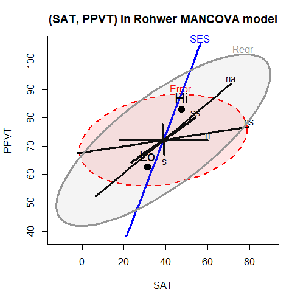

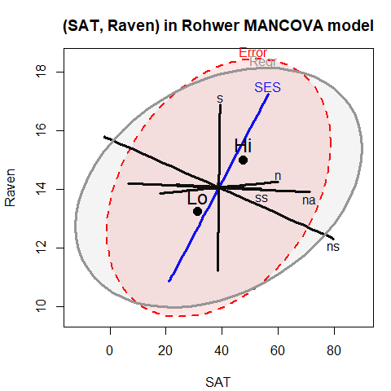

Figure 1.4: HE plot for `SAT` and `PPVT` (left) and for `SAT` and `Raven` (right) using the MANCOVA model. The ellipses labeled ‘Regr’ show the test of the overall model, including all predictors.

```r
colors <- c("red", "blue", rep("black",5), "#969696")
heplot(Rohwer.mod,
       col=colors, variables=c(1,2),
       hypotheses=list("Regr" = covariates),
       fill = TRUE, fill.alpha = 0.1,
       cex=1.5, lwd=c(2, rep(3,5), 4),
       main="(SAT, PPVT) in Rohwer MANCOVA model")

heplot(Rohwer.mod,
       col=colors,  variables=c(1,3),
       hypotheses=list("Regr" = covariates),
       fill = TRUE, fill.alpha = 0.1,
       cex=1.5, lwd=c(2, rep(3,5), 4),
       main="(SAT, Raven) in Rohwer MANCOVA model")
```

The positive orientation of the `Regr` ellipses shows that the predicted values for all three responses are positively correlated (more so for `SAT` and `PPVT`). As well, the High SES group is higher on all responses than the Low SES group.

Alternatively, all pairwise plots among these responses could be drawn using the `pairs.mlm()` function,

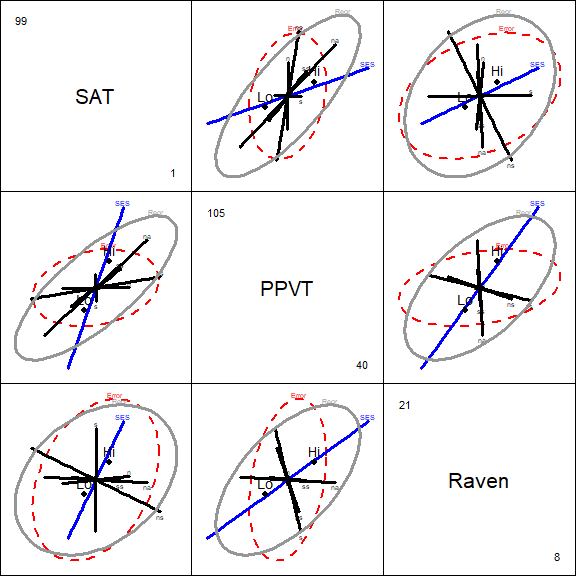

```r
pairs(Rohwer.mod, col=colors,
      hypotheses=list("Regr" = c("n", "s", "ns", "na", "ss")),
      cex=1.3, lwd=c(2, rep(3,5), 4))
```

or as a 3D plot, using `heplot3d()` as shown in Figure 1.5.

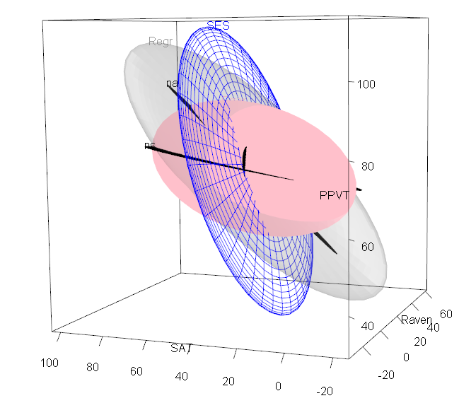

Figure 1.5: 3D HE plot for the MANCOVA model fit to the Rohwer data.

```r
colors <- c("pink", "blue", rep("black",5), "#969696")
heplot3d(Rohwer.mod, col=colors,
    hypotheses=list("Regr" = c("n", "s", "ns", "na", "ss")))
```

## 1.4 Testing homogeneity of regression

The MANCOVA model, `Rohwer.mod`, has relatively simple interpretations (large effect of `SES`, with `ns` and `na` as the major predictors) but the test of the `SES` effect relies on the assumption of homogeneity of slopes for the predictors. We can test this assumption as follows, by adding interactions of `SES` with each of the covariates:

```r
Rohwer.mod2 <- lm(cbind(SAT, PPVT, Raven) ~ SES * (n + s + ns + na + ss),
                  data=Rohwer)
Anova(Rohwer.mod2)
```

```
#>
#> Type II MANOVA Tests: Pillai test statistic
#>        Df test stat approx F num Df den Df  Pr(>F)
#> SES     1     0.391    11.78      3     55 4.5e-06 ***
#> n       1     0.079     1.57      3     55 0.20638
#> s       1     0.125     2.62      3     55 0.05952 .
#> ns      1     0.254     6.25      3     55 0.00100 ***
#> na      1     0.307     8.11      3     55 0.00015 ***
#> ss      1     0.060     1.17      3     55 0.32813
#> SES:n   1     0.072     1.43      3     55 0.24417
#> SES:s   1     0.099     2.02      3     55 0.12117
#> SES:ns  1     0.118     2.44      3     55 0.07383 .
#> SES:na  1     0.148     3.18      3     55 0.03081 *
#> SES:ss  1     0.057     1.12      3     55 0.35094
#> ---
#> Signif. codes:  0 '***' 0.001 '**' 0.01 '*' 0.05 '.' 0.1 ' ' 1
```

It appears from the above that there is only weak evidence of unequal slopes from the separate `SES:` terms. The evidence for heterogeneity is stronger, however, when these terms are tested collectively using the `linearHypothesis()` function:

```r
# test interaction terms jointly
coefs <- rownames(coef(Rohwer.mod2))
interactions <- coefs[grep(":", coefs)] |> print()
```

```
#> [1] "SESLo:n"  "SESLo:s"  "SESLo:ns" "SESLo:na" "SESLo:ss"
```

```r
print(linearHypothesis(Rohwer.mod2, interactions), SSP=FALSE)
```

```
#>
#> Multivariate Tests:
#>                  Df test stat approx F num Df den Df  Pr(>F)
#> Pillai            5    0.4179    1.845     15  171.0 0.03209 *
#> Wilks             5    0.6236    1.894     15  152.2 0.02769 *
#> Hotelling-Lawley  5    0.5387    1.927     15  161.0 0.02396 *
#> Roy               5    0.3846    4.385      5   57.0 0.00191 **
#> ---
#> Signif. codes:  0 '***' 0.001 '**' 0.01 '*' 0.05 '.' 0.1 ' ' 1
```

This model (`Rohwer.mod2`) is similar in spirit to the two models (`rohwer.ses1` and `rohwer.ses2`) fit for the two SES groups separately and show in Figure 1.3, except that model `Rohwer.mod2` assumes a common within-groups error covariance matrix and allows overall tests.

To illustrate model `Rohwer.mod2`, we construct an HE plot for `SAT` and `PPVT` shown in Figure 1.6. To simplify this display, we show the hypothesis ellipses for the overall effects of the PA tests in the baseline high-SES group, and a single combined ellipse for all the `SESLo:` interaction terms that we tested previously, representing differences in slopes between the low and high-SES groups.

Because SES is “treatment-coded” in this model, the ellipse for each covariate represents the hypothesis that the slopes for that covariate are zero in the high-SES baseline category. With this parameterization, the ellipse for `Slopes` represents the joint hypothesis that slopes for the covariates do not differ in the low-SES group.

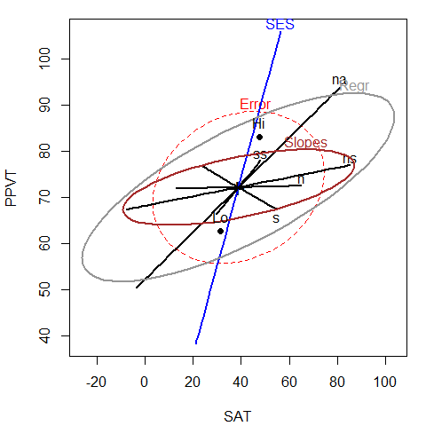

Figure 1.6: HE plot for `SAT` and `PPVT`, fitting the model `Rohwer.mod2` that allows unequal slopes for the covariates.

```r
colors <- c("red", "blue", rep("black",5), "#969696")
heplot(Rohwer.mod2, col=c(colors, "brown"),
      terms=c("SES", "n", "s", "ns", "na", "ss"),
      hypotheses=list("Regr" = c("n", "s", "ns", "na", "ss"),
                      "Slopes" = coefs[grep(":", coefs)]))
```

Comparing Figure 1.6 for the heterogeneous slopes model with Figure 1.4 (left) for the homogeneous slopes model, it can be seen that most of the covariates have ellipses of similar size and orientation, reflecting similar evidence against the respective null hypotheses, as does the effect of `SES`, showing the greater performance of the high-SES group on all response measures. Somewhat more subtle, the error ellipse is noticeably smaller in Figure 1.6, reflecting the additional variation accounted for by differences in slopes.

# 2 Recovery from hernia repair

This example uses the `Hernior` data (from Mosteller & Tukey (1977), Data Exhibit 8, p. 567-568), comprising data on measures of post-operative recovery of 32 patients undergoing an elective herniorrhaphy operation, in relation to pre-operative measures.

The outcome measures are:

- `leave`, the patient’s condition upon leaving the recovery room (a 1-4 scale, 1=best),
- `nurse`, level of nursing required one week after operation (a 1-5 scale, 1=worst) and
- `los`, length of stay in hospital after operation (in days)

The predictor variables are:

- patient `age`, `sex`,
- `pstat, physical status ( a 1-5 scale, with 1=perfect health, …, 5=very poor health),
- `build`, body build (a 1-5 scale, with 1=emaciated, …, 5=obese), and
- preoperative complications with (`cardiac`) heart and respiration (`resp`), 1-4 scales, 1=none, …, 4=severe.

```r
data(Hernior)
str(Hernior)
```

```
#> 'data.frame':    32 obs. of  9 variables:
#>  $ age    : int  78 60 68 62 76 76 64 74 68 79 ...
#>  $ sex    : Factor w/ 2 levels "f","m": 2 2 2 2 2 2 2 1 2 1 ...
#>  $ pstat  : int  2 2 2 3 3 1 1 2 3 2 ...
#>  $ build  : int  3 3 3 5 4 3 2 3 4 2 ...
#>  $ cardiac: int  1 2 1 3 3 1 1 2 2 1 ...
#>  $ resp   : int  1 2 1 1 2 1 2 2 1 1 ...
#>  $ leave  : int  2 2 1 1 2 1 1 1 1 2 ...
#>  $ los    : int  9 4 7 35 9 7 5 16 7 11 ...
#>  $ nurse  : num  3 5 4 3 4 5 5 3 5 3 ...
```

## 2.1 All predictors model

We begin with a model fitting all predictors. Note that the ordinal predictors, `pstat`, `build`, `cardiac` and `resp` could arguably be treated as factors, rather than linear, regression terms. Doing so would give tests for nonlinear effects of their relations with the responses. We ignore this possibility in this example.

```r
Hern.mod <- lm(cbind(leave, nurse, los) ~ age + sex +  pstat +  build + cardiac + resp,
               data=Hernior)
Anova(Hern.mod)
```

```
#>
#> Type II MANOVA Tests: Pillai test statistic
#>         Df test stat approx F num Df den Df Pr(>F)
#> age      1     0.143     1.27      3     23  0.307
#> sex      1     0.026     0.21      3     23  0.892
#> pstat    1     0.333     3.84      3     23  0.023 *
#> build    1     0.257     2.65      3     23  0.073 .
#> cardiac  1     0.228     2.26      3     23  0.108
#> resp     1     0.248     2.53      3     23  0.082 .
#> ---
#> Signif. codes:  0 '***' 0.001 '**' 0.01 '*' 0.05 '.' 0.1 ' ' 1
```

The results of the multivariate tests above are somewhat disappointing. Only the physical status predictor (`pstat`) appears to be significant at conventional levels.

The univariate models for each response are implicit in the MLM `Hern.mod`. These can be printed using `summary()`, or we can use `summary()` to extract certain statistics for each univariate response model, as we do here.

```r
Hern.summary <- summary(Hern.mod)
unlist(lapply(Hern.summary, function(x) x$r.squared))
```

```
#> Response leave Response nurse   Response los
#>         0.5918         0.2474         0.3653
```

More conveniently, the function `heplots::glance.mlm()` extends `broom::glance.lm()` to give a one-line summary of statistics for each response variable in a MLM. The $R^2$ and $F$ statistics are those for each overall model assessing the impact of all predictors.

```r
glance.mlm(Hern.mod)
```

```
#> # A tibble: 3 × 8
#>   response r.squared sigma fstatistic numdf dendf  p.value  nobs
#>   <chr>        <dbl> <dbl>      <dbl> <dbl> <dbl>    <dbl> <int>
#> 1 leave        0.592 0.388       6.04     6    25 0.000519    32
#> 2 nurse        0.247 0.841       1.37     6    25 0.265       32
#> 3 los          0.365 5.62        2.40     6    25 0.0573      32
```

Univariate tests for predictors in each of these models (not shown here) are hard to interpret, and largely show only significant effects for the `leave` variable. Yet, the $R^2$ values for the other responses are slightly promising. We proceed to a multivariate overall test of $\mathbf{B} = 0$ for all predictors, whose term names can be easily extracted from the rownames of the coefficients.

```r
# test overall regression
(predictors <- rownames(coef(Hern.mod))[-1])
```

```
#> [1] "age"     "sexm"    "pstat"   "build"   "cardiac" "resp"
```

```r
Regr <- linearHypothesis(Hern.mod, predictors)
print(Regr, digits=5, SSP=FALSE)
```

```
#>
#> Multivariate Tests:
#>                  Df test stat approx F num Df den Df    Pr(>F)
#> Pillai            6   1.10198   2.4192     18 75.000 0.0041356 **
#> Wilks             6   0.21734   2.6046     18 65.539 0.0025239 **
#> Hotelling-Lawley  6   2.26797   2.7300     18 65.000 0.0016285 **
#> Roy               6   1.55434   6.4764      6 25.000 0.0003232 ***
#> ---
#> Signif. codes:  0 '***' 0.001 '**' 0.01 '*' 0.05 '.' 0.1 ' ' 1
```

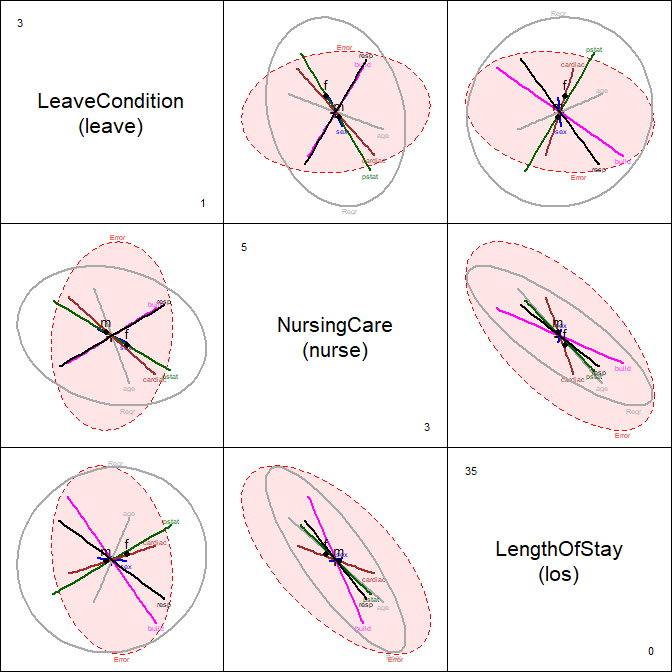

Figure 2.1: HE pairs plot for Hernior data

```r
clr <- c("red", "darkgray", "blue", "darkgreen", "magenta", "brown", "black")
vlab <- c("LeaveCondition\n(leave)",
          "NursingCare\n(nurse)",
          "LengthOfStay\n(los)")

hyp <- list("Regr" = predictors)
pairs(Hern.mod,
      hypotheses=hyp,
      col=clr, var.labels=vlab,
      fill=c(TRUE,FALSE), fill.alpha = 0.1,
      cex=1.25)
```

A `pairs()` plot for the MLM gives the set of plots shown in Figure 2.1 helps to interpret the relations among the predictors which lead to the highly significant overall test. Among the predictors, age and sex have small and insignificant effects on the outcome measures jointly. The other predictors all contribute to the overall test of $\mathbf{B} = 0$, though in different ways for the various responses. For example, in the panel for (`leave`, `los`) in Figure 2.1, it can be seen that while only `pstat` individually is outside the $\mathbf{E}$ ellipse, `build` and `resp` contribute to the overall test in an opposite direction.

## 2.2 Canonical analysis

In this multivariate regression example, all of the terms in the model `Hern.mod` have 1 df, and so plot as lines in HE plots. An alternative view of these effects can be seen in canonical discriminant space, which, for each predictor shows the scores on the linear combination of the responses that contributes most to the multivariate test of that effect, together with the weights for the responses.

We use `candiscList()` to calculate the canonical analyses for all predictor terms in `Hern.mod`.

```r
Hern.canL <- candiscList(Hern.mod)
```

1D canonical discriminant plots for all terms can be obtained interactively with a menu, simply by plotting the `Hern.canL` object.

```r
plot(Hern.canL)
```

Plots for separate terms are produced by the lines below, and shown in Figure 2.2 and Figure 2.3.

For `pstat` and `build`:

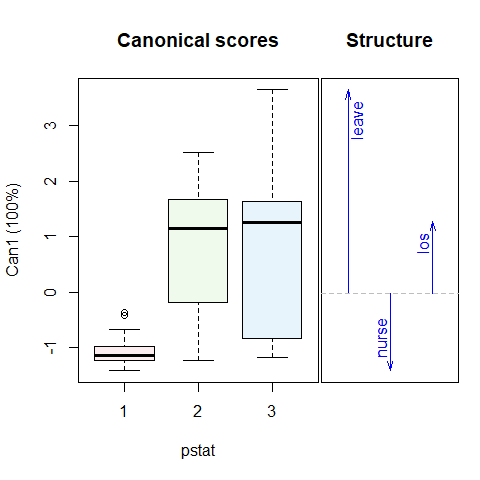

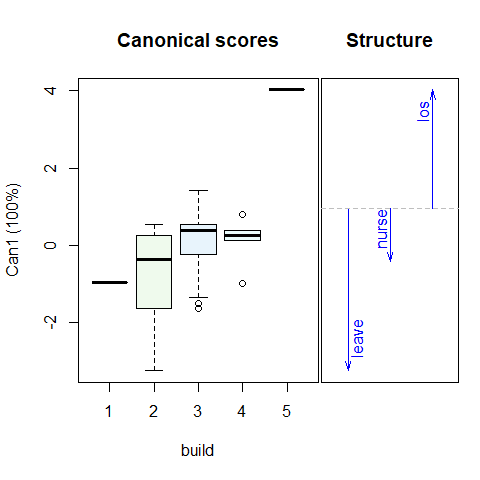

Figure 2.2: 1D Canonical discriminant plots for physical status (`pstat`) and `build`. The canonical scores are such that better outcomes are associated with smaller scores. Arrows show the correlations of the responses with the 1D canonical scores.

```r
plot(Hern.canL, term="pstat")
plot(Hern.canL, term="build")
```

For `age` and `cardiac`:

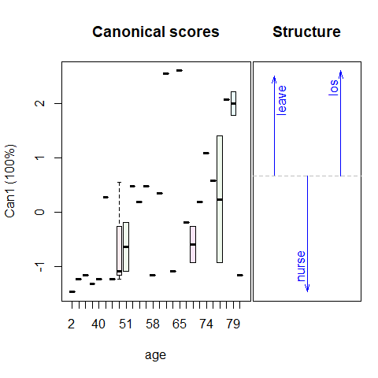

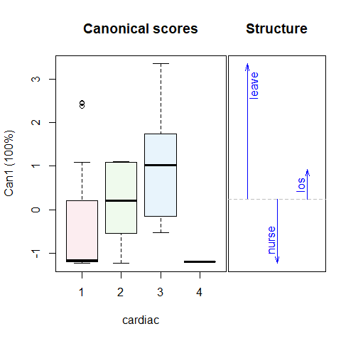

Figure 2.3: 1D Canonical discriminant plots for `age` and `cardiac`. The canonical scores are such that better outcomes are associated with smaller scores.

```r
plot(Hern.canL, term="age")
plot(Hern.canL, term="cardiac")
```

These plots provide simple interpretations of the results for the canonical combinations of the responses. Better physical status, smaller body build, lower age and absence of cardiac complications are all positively related to better outcomes.

# 3 Grades in a Sociology Course

The data set `SocGrades` contains four outcome measures on student performance in an introductory sociology course together with six potential predictors. These data were used by Marascuilo & Levin (1983) for an example of canonical correlation analysis, but are also suitable as examples of multivariate multiple regression, MANOVA, MANCOVA and step-down analysis in multivariate linear models.

The outcome measures used here are three test scores during the course, `midterm1`, `midterm2`, `final`, and a course evaluation (`eval`).[^1]

Predictor variables are:

- `class`, the student’s social class (an ordered factor with levels `1` > `2` > `3`)
- `sex`,
- `gpa`, grade point average,
- `boards`, College Board test scores,
- `hssoc`, previous high school unit in sociology? (with values `no`, `yes`), and
- `pretest`, score on a course pretest.

```r
str(SocGrades)
```

```
#> 'data.frame':    40 obs. of  10 variables:
#>  $ class   : Ord.factor w/ 3 levels "3"<"2"<"1": 2 2 2 1 2 1 3 2 1 2 ...
#>  $ sex     : Factor w/ 2 levels "F","M": 2 2 2 2 2 2 1 2 2 1 ...
#>  $ gpa     : num  3.55 2.7 3.5 2.91 3.1 3.49 3.17 3.57 3.76 3.81 ...
#>  $ boards  : int  410 390 510 430 600 610 610 560 700 460 ...
#>  $ hssoc   : Factor w/ 2 levels "no","yes": 1 1 1 1 1 1 1 1 2 2 ...
#>  $ pretest : int  17 20 22 13 16 28 14 10 28 30 ...
#>  $ midterm1: int  43 50 47 24 47 57 42 42 69 48 ...
#>  $ midterm2: int  61 47 79 40 60 59 61 79 83 67 ...
#>  $ final   : int  129 60 119 100 79 99 92 107 156 110 ...
#>  $ eval    : int  3 1 1 1 2 1 3 2 1 1 ...
```

## 3.1 Models

The basic MLM is fit below as `grades.mod` with all predictor variables.

```r
data(SocGrades)
grades.mod <- lm(cbind(midterm1, midterm2, final, eval) ~
                         class + sex + gpa + boards + hssoc + pretest,
                 data=SocGrades)
Anova(grades.mod, test="Roy")
```

```
#>
#> Type II MANOVA Tests: Roy test statistic
#>         Df test stat approx F num Df den Df  Pr(>F)
#> class    2     1.567    11.75      4     30 7.3e-06 ***
#> sex      1     0.553     4.01      4     29  0.0104 *
#> gpa      1     1.208     8.76      4     29 9.2e-05 ***
#> boards   1     0.731     5.30      4     29  0.0025 **
#> hssoc    1     0.035     0.25      4     29  0.9052
#> pretest  1     0.313     2.27      4     29  0.0859 .
#> ---
#> Signif. codes:  0 '***' 0.001 '**' 0.01 '*' 0.05 '.' 0.1 ' ' 1
```

### 3.1.1 Screening for interactions

In both univariate and multivariate response models, it is often useful to screen for higher-order terms (interactions, non-linear predictors). This can most easily be done using `update()`, as we do below. First, try the extended model with all pairwise interactions of the predictors. In the model formula, `~.^2`, the `.` represents all terms in the model, and the `^2` generates all products of terms, such as `class:sex`, `class:gpa`, and so forth.

```r
grades.mod2 <- update(grades.mod, . ~ .^2)
Anova(grades.mod2, test="Roy")
```

```
#>
#> Type II MANOVA Tests: Roy test statistic
#>                Df test stat approx F num Df den Df Pr(>F)
#> class           2     2.817     7.04      4     10 0.0058 **
#> sex             1     0.487     1.09      4      9 0.4152
#> gpa             1     1.998     4.49      4      9 0.0286 *
#> boards          1     2.338     5.26      4      9 0.0183 *
#> hssoc           1     0.281     0.63      4      9 0.6522
#> pretest         1     0.510     1.15      4      9 0.3946
#> class:sex       2     2.039     5.10      4     10 0.0168 *
#> class:gpa       2     0.982     2.45      4     10 0.1137
#> class:boards    2     0.522     1.31      4     10 0.3321
#> class:hssoc     2     0.356     0.89      4     10 0.5041
#> class:pretest   2     1.005     2.51      4     10 0.1082
#> sex:gpa         1     0.269     0.60      4      9 0.6694
#> sex:boards      1     0.184     0.41      4      9 0.7944
#> sex:hssoc       1     0.909     2.04      4      9 0.1714
#> sex:pretest     1     0.885     1.99      4      9 0.1795
#> gpa:boards      1     0.447     1.00      4      9 0.4537
#> gpa:hssoc       1     0.596     1.34      4      9 0.3269
#> gpa:pretest     1     0.472     1.06      4      9 0.4291
#> boards:hssoc    1     0.353     0.80      4      9 0.5573
#> boards:pretest  1     0.705     1.59      4      9 0.2593
#> hssoc:pretest   1     1.464     3.29      4      9 0.0635 .
#> ---
#> Signif. codes:  0 '***' 0.001 '**' 0.01 '*' 0.05 '.' 0.1 ' ' 1
```

In the results above, only the interaction of `class:sex` is significant, and the main effects of `hssoc` and `pretest` remain insignificant. A revised model to explore is `grades.mod3`,

```r
grades.mod3 <- update(grades.mod, . ~ . + class:sex - hssoc - pretest)
Anova(grades.mod3, test="Roy")
```

```
#>
#> Type II MANOVA Tests: Roy test statistic
#>           Df test stat approx F num Df den Df  Pr(>F)
#> class      2     1.588    11.91      4     30 6.5e-06 ***
#> sex        1     0.575     4.17      4     29 0.00864 **
#> gpa        1     1.434    10.40      4     29 2.4e-05 ***
#> boards     1     0.895     6.49      4     29 0.00074 ***
#> class:sex  2     0.450     3.38      4     30 0.02143 *
#> ---
#> Signif. codes:  0 '***' 0.001 '**' 0.01 '*' 0.05 '.' 0.1 ' ' 1
```

A pairwise HE plot for all responses (Figure 3.1 shows that nearly all effects are in the expected directions: higher `gpa`, `boards`, `class` leads to better performance on most outcomes. The interaction of `class:sex` seems to be confined largely to `midterm1`.

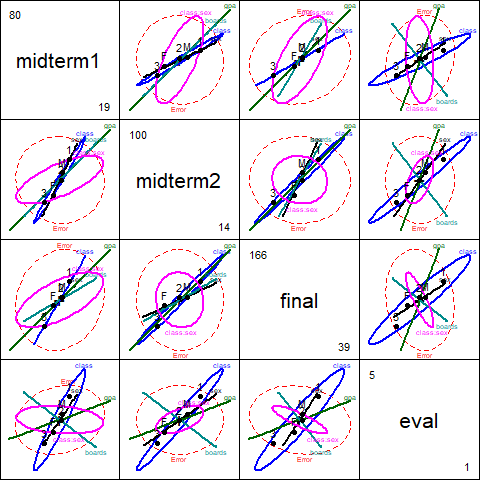

Figure 3.1: HE pairs plot for SocGrade, model `grades.mod3`.

```r
pairs(grades.mod3)
```

These effects are easier to appreciate for the three exam grades jointly in a 3D HE plot when you can rotate it interactively. A snapshot is shown in Figure 3.2.

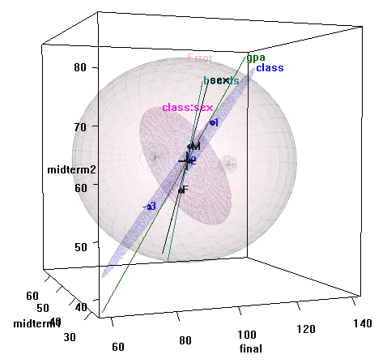

Figure 3.2: 3D HE plot for SocGrades, model `grades.mod3`

```r
heplot3d(grades.mod3, wire=FALSE)
```

Interactive rotation of this plot shows that the effect of `class` is only two dimensional, and of these, one dimension is very small. The major axis of the `class` ellipsoid is aligned with increasing performance on all three grades, with the expected ordering of the three social classes.

## 3.2 Canonical analysis

The representation of these effects in canonical space is particularly useful here. Again, use `candiscList()` to compute the canonical decompositions for all terms in the model, and extract the canonical $R^2$ from the terms in the result.

```r
# calculate canonical results for all terms
grades.can <- candiscList(grades.mod3)
# extract canonical R^2s
unlist(lapply(grades.can, function(x) x$canrsq))
```

```
#>     class1     class2        sex        gpa     boards class:sex1 class:sex2
#>    0.61362    0.02419    0.36527    0.58915    0.47227    0.31046    0.13293
```

We use `heplot()` on the `"candiscList"` object to show the effects of `class` in canonical space, giving Figure 3.3.

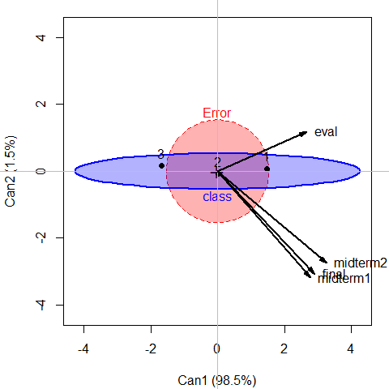

Figure 3.3: Canonical HE plot for `class` effect in `grades.mod3`

```r
# plot class effect in canonical space
 heplot(grades.can, term="class",
        scale=4, fill=TRUE, var.col="black", var.lwd=2)
```

It can be seen in Figure 3.3 that nearly all variation in exam performance due to class is aligned with the first canonical dimension. The three tests and course evaluation all have similar weights on this dimension, but the course evaluation differs from the rest along a second, very small dimension.

1D plots of the canonical scores for other effects in the model are also of interest, and provide simple interpretations of these effects on the response variables. The statements below produce the plots shown in Figure 3.4.

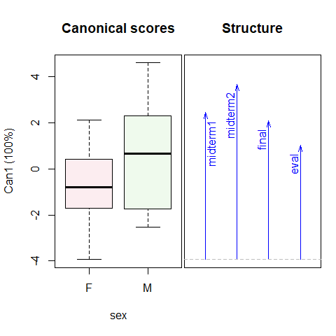

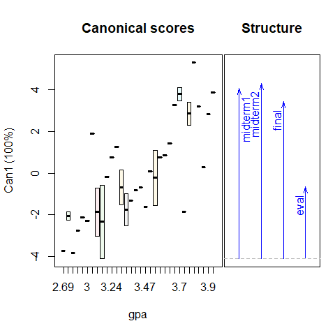

Figure 3.4: 1D Canonical discriminant plots for `sex` and `gpa`. Higher canonical scores reflect better course performance.

```r
plot(grades.can, term="sex")
plot(grades.can, term="gpa")
```

It is readily seen that males perform better overall, but the effect of `sex` is strongest for the `midterm2`. As well, increasing course performance on tests is strongly associated with `gpa`.

## References

Marascuilo, L. A., & Levin, J. R. (1983). *Multivariate statistics in the social sciences: A researcher’s guide*. Brooks/Cole Publishing Company.

Mosteller, F., & Tukey, J. W. (1977). *Data analysis and regression: A second course in statistics*. Reading: Addison-Wesley.

Timm, N. H. (1975). *Multivariate analysis with applications in education and psychology*. Belmont, CA: Wadsworth (Brooks/Cole).

[^1]: It is arguable that the students’ course evaluation should not be considered a response variable here. It could be used as a predictor in a follow-up, step-down analysis, which would address the separate question of whether the effects on exam grades remain, when `eval` is controlled for.